# Vehicle Detection based on YOLOv2

Some function code come from Andrew's cousera course(deeplearning.ai) and https://github.com/allanzelener/YAD2K

```python
import argparse
import os
import matplotlib.pyplot as plt
from matplotlib.pyplot import imshow
import scipy.io
import scipy.misc
import numpy as np
import pandas as pd
import PIL
import tensorflow as tf
from keras import backend as K
from keras.layers import Input, Lambda, Conv2D, Concatenate , BatchNormalization, LeakyReLU, MaxPooling2D,Reshape
from keras.models import load_model, Model
from keras.optimizers import Adam
from keras.layers.merge import concatenate
from PIL import Image, ImageDraw, ImageFont
from sklearn.utils import shuffle
import random
import matplotlib.image as mpimg
import pandas as pd
from utils import *
%matplotlib inline
```

## Data preparation

Udacity provide us with 2 dataset. So in this section I will combine the information from 2 dataset into 1 csv file

```python
dir_label = ['object-dataset',
            'object-detection-crowdai']
df_files1 = pd.read_csv('object-detection-crowdai.csv', header=0)
#As we are doing vehicle detection, I discard other class for object detection like pedestrian.
df_vehicles1 = df_files1[(df_files1['Label']=='Car') | (df_files1['Label']=='Truck')].reset_index()
df_vehicles1 = df_vehicles1.drop('index', 1)
df_vehicles1['File_Path'] =  dir_label[1] + '/' +df_vehicles1['Frame']
df_vehicles1 = df_vehicles1.drop('Preview URL', 1)
```

```python
df_files2 = pd.read_csv('object-dataset.csv', header=None)
df_files2.columns = ['Frame', 'xmin' , 'xmax', 'ymin', 'ymax', 'ind', 'Label' , 'RM']
df_vehicles2 = df_files2[(df_files2['Label']=='car') | (df_files2['Label']=='truck')].reset_index()
df_vehicles2 = df_files2[(df_files2['Label']=='car') | (df_files2['Label']=='truck')].reset_index()
df_vehicles2 = df_vehicles2.drop('index', 1)
df_vehicles2 = df_vehicles2.drop('RM', 1)
df_vehicles2 = df_vehicles2.drop('ind', 1)
df_vehicles2['File_Path'] = dir_label[0] + '/' +df_vehicles2['Frame']
```

```python
#Combine 2 dataset into 1 csv file.
df_vehicles = pd.concat([df_vehicles1,df_vehicles2]).reset_index()
df_vehicles = df_vehicles.drop('index', 1)
df_vehicles.columns =['File_Path','Frame','Label','ymin','xmin','ymax','xmax']

#Doing some calculation so training data preprocess later will be easy.
df_vehicles['x'] = (df_vehicles['xmax'] +df_vehicles['xmin'])/2
df_vehicles['y'] = (df_vehicles['ymax'] + df_vehicles['ymin'])/2


df_vehicles['x_center'] = df_vehicles['x']/(train_image_shape[0]/19)
df_vehicles['y_center'] = df_vehicles['y']/(train_image_shape[1]/19)

df_vehicles['w'] = (df_vehicles['xmax'] - df_vehicles['xmin'])
df_vehicles['h'] = (df_vehicles['ymax'] - df_vehicles['ymin'])
df_vehicles['w_center'] = df_vehicles['w']/(train_image_shape[0]/19)
df_vehicles['h_center'] = df_vehicles['h']/(train_image_shape[1]/19)

df_vehicles['i'] = (df_vehicles['x']/train_image_shape[0]) * 19
df_vehicles['j'] = (df_vehicles['y']/train_image_shape[1]) * 19

df_vehicles['i'] = df_vehicles['i'].astype(int)
df_vehicles['j'] = df_vehicles['j'].astype(int)

df_vehicles["class"] = df_vehicles["Label"].map({'Car':0, 'Truck':1 , 'car':0, 'truck':1}).astype(int)

df_vehicles = pd.get_dummies(df_vehicles,columns = ['class'])

df_vehicles.to_csv('whole.csv')
df_vehicles.head()
```

|  | File_Path | Frame | Label | ymin | xmin | ymax | xmax | x | y | x_center | y_center | w | h | w_center | h_center | i | j | class_0 | class_1 |
| --- | --- | --- | --- | --- | --- | --- | --- | --- | --- | --- | --- | --- | --- | --- | --- | --- | --- | --- | --- |
| 0 | object-detection-crowdai/1479498371963069978.jpg | 1479498371963069978.jpg | Car | 533 | 785 | 644 | 905 | 845.0 | 588.5 | 8.361979 | 9.317917 | 120 | 111 | 1.187500 | 1.757500 | 8 | 9 | 1 | 0 |
| 1 | object-detection-crowdai/1479498371963069978.jpg | 1479498371963069978.jpg | Car | 551 | 89 | 680 | 291 | 190.0 | 615.5 | 1.880208 | 9.745417 | 202 | 129 | 1.998958 | 2.042500 | 1 | 9 | 1 | 0 |
| 2 | object-detection-crowdai/1479498371963069978.jpg | 1479498371963069978.jpg | Car | 546 | 268 | 650 | 383 | 325.5 | 598.0 | 3.221094 | 9.468333 | 115 | 104 | 1.138021 | 1.646667 | 3 | 9 | 1 | 0 |
| 3 | object-detection-crowdai/1479498371963069978.jpg | 1479498371963069978.jpg | Truck | 522 | 455 | 615 | 548 | 501.5 | 568.5 | 4.962760 | 9.001250 | 93 | 93 | 0.920312 | 1.472500 | 4 | 9 | 0 | 1 |
| 4 | object-detection-crowdai/1479498371963069978.jpg | 1479498371963069978.jpg | Truck | 522 | 548 | 605 | 625 | 586.5 | 563.5 | 5.803906 | 8.922083 | 77 | 83 | 0.761979 | 1.314167 | 5 | 8 | 0 | 1 |

When I come back later, I can start from here.

```python
df_vehicles = pd.read_csv('whole.csv')
df_vehicles = df_vehicles.drop('Unnamed: 0', 1)
df_vehicles.head(1)
```

|  | File_Path | Frame | Label | ymin | xmin | ymax | xmax | x | y | x_center | y_center | w | h | w_center | h_center | i | j | class_0 | class_1 |
| --- | --- | --- | --- | --- | --- | --- | --- | --- | --- | --- | --- | --- | --- | --- | --- | --- | --- | --- | --- |
| 0 | object-detection-crowdai/1479498371963069978.jpg | 1479498371963069978.jpg | Car | 533 | 785 | 644 | 905 | 845.0 | 588.5 | 8.361979 | 9.317917 | 120 | 111 | 1.1875 | 1.7575 | 8 | 9 | 1 | 0 |

## Data preprocess

Output of the yolo is a 19*19 grid feature map. If the centre of the box is located in a grid, then this grid is responsible for containing the information about this box. For each grid, we prepared 5 anchor boxes.

```python
grid_num = 19
image_file = []
n = len(df_vehicles)
target = np.zeros((22065,grid_num,grid_num,5,7))
file_name = []
num = -1
anchors_box = [BoundBox(0, 0, ANCHORS[2*i], ANCHORS[2*i+1]) for i in range(int(len(ANCHORS)/2))]
# Iterating through the whole csv file to get all the image file names.
for i in range(n):
    row = df_vehicles.iloc[i]
    x_filename = row['File_Path']
    if x_filename != file_name:
        file_name = x_filename
        image_file.append(file_name)
        num = num +1
    center_x = row['x_center']
    center_y = row['y_center']
    center_w = row['w_center']
    center_h = row['h_center']
    box = [center_x, center_y, center_w, center_h]
    shifted_box = BoundBox(0, 0, center_w, center_h) # We shifted the ground truth box to the center of the grid to caculate the IOU.
    best_anchor = -1
    max_iou  = -1
    # Iterating through all anchor box to calculate the IOU. And place the ground truth box with the max IOU anchor box.
    for j in range(len(anchors_box)):
        right_anchor = anchors_box[j]
        iou = bbox_iou(shifted_box, right_anchor)
        if max_iou < iou:
            best_anchor = j
            max_iou = iou
    target[num][int(row['i'])][int(row['j'])][best_anchor] = \
     row['x_center']/grid_num, row['y_center']/grid_num, row['w_center']/grid_num, row['h_center']/grid_num, 1,row['class_0'], row['class_1']
```

## Building the Network

I rewrite the yolo network based on the 'yolo.png' image. But this part is not used. Because training yolo is too computational expensive for me.Using pre-trained weights is more practical to me.

```python
'''
def block1(inputs, layer_num = '1', output_num = 32, filter_size = 3):
    conv = Conv2D(filters = output_num,kernel_size = (filter_size,filter_size) ,strides = (1,1), padding = 'same',  use_bias=False,name = 'conv2d' + layer_num)(inputs)
    batch_norm = BatchNormalization(name = 'batch_norm' + layer_num)(conv)
    leaky_relu = LeakyReLU(name = 'leaky_relu' + layer_num)(batch_norm)
    maxpooling2d = MaxPooling2D(pool_size = (2,2), strides =(2,2), name = 'MaxPooling2D' + layer_num)(leaky_relu)
    return maxpooling2d

def block2(inputs, layer_num = '1',  output_num = 32, filter_size = 3):
    conv = Conv2D(filters = output_num,kernel_size = (filter_size,filter_size) ,strides = (1,1), padding = 'same', use_bias=False, name = 'conv2d' + layer_num)(inputs)
    batch_norm = BatchNormalization(name = 'batch_norm' + layer_num)(conv)
    leaky_relu = LeakyReLU(name = 'leaky_relu' + layer_num)(batch_norm)
    return leaky_relu

pic_inputs = Input(shape = (608,608,3,), dtype = 'float32', name = 'pic_input')
yolo = block1(pic_inputs, layer_num = '1', output_num = 32)  #304*304*32
yolo = block1(yolo, layer_num = '2', output_num = 64) #152*152*64
yolo = block2(yolo, layer_num = '3', output_num = 128) #152*152*128
yolo = block2(yolo, layer_num = '4', output_num = 64, filter_size = 1) #152*152*64
yolo = block1(yolo, layer_num = '5', output_num = 128) #76*76*128
yolo = block2(yolo, layer_num = '6', output_num = 256) #76*76*256
yolo = block2(yolo, layer_num = '7', output_num = 128, filter_size = 1) #76*76*128
yolo = block1(yolo, layer_num = '8', output_num = 256) #38*38*256
yolo = block2(yolo, layer_num = '9', output_num = 512) #38*38*512
yolo = block2(yolo, layer_num = '10', output_num = 256, filter_size = 1) #38*38*256
yolo = block2(yolo, layer_num = '11', output_num = 512) #38*38*512
yolo = block2(yolo, layer_num = '12', output_num = 256, filter_size = 1) #38*38*256
#yolo = block2(yolo, layer_num = '13')
conv2d_13 = Conv2D(filters = 512,kernel_size = (3,3) ,strides = (1,1), padding = 'same', name = 'conv2d13')(yolo)#38*38*512
batch_norm_13 = BatchNormalization(name = 'batch_norm13')(conv2d_13)
leaky_relu_13 = LeakyReLU(name = 'leaky_relu13')(batch_norm_13)
MaxPooling2D_13 = MaxPooling2D(pool_size = (2,2), strides =(2,2), name = 'MaxPooling2D13')(leaky_relu_13) #19*19*512
yolo = block2(MaxPooling2D_13, layer_num = '14', output_num = 1024) #19*19*1024
yolo = block2(yolo, layer_num = '15', output_num = 512, filter_size = 1) #19*19*512
yolo = block2(yolo, layer_num = '16', output_num = 1024) #19*19*1024
yolo = block2(yolo, layer_num = '17', output_num = 512, filter_size = 1) #19*19*512
yolo = block2(yolo, layer_num = '18', output_num = 1024) #19*19*1024
yolo = block2(yolo, layer_num = '19', output_num = 1024) #19*19*1024
yolo = block2(yolo, layer_num = '20', output_num = 1024) #19*19*1024

conv2d_21 = Conv2D(filters = 64,kernel_size = (3,3) ,strides = (1,1), padding = 'same', name = 'conv2d21')(leaky_relu_13)#38*38*64
batch_norm_21 = BatchNormalization(name = 'batch_norm21')(conv2d_21)
leaky_relu_21 = LeakyReLU(name = 'leaky_relu21')(batch_norm_21)
space_to_depth = tf.space_to_depth(leaky_relu_13, block_size = 2, name = 'space_to_depth')#19*19*256
concat = Concatenate(axis = -1)([yolo, space_to_depth])#19*19*1280
yolo = block2(concat, layer_num = '22', output_num = 1024) #19*19*1024
yolo = Conv2D(filters = 425,kernel_size = (1,1) ,strides = (1,1), padding = 'same', name = 'conv2d21')(leaky_relu_13)

my_yolo_model = Model(inputs = pic_inputs, outputs = yolo)


'''
```

I loaded pre-trained weights, and build the last 2 convolutional layers. I'm going to lock the weights on all the model except last 2 layers. Because the yolo model predict 80 classes, so the final output size is 19x19x5x(5+80). For my own model, I predict only car and truck, so the final output size is 19x19x5x(5+2). But this way isn't working. After several eopochs of training, model predicts bad

```python
yolo_model = load_model("model_data/yolo.h5")
yolo_output = yolo_model.get_layer('concatenate_1').output
conv2d_22 = Conv2D(filters = 512,kernel_size = (3,3) ,strides = (1,1), padding = 'same', name = 'conv2d22', use_bias=False)(yolo_output)
batch_norm_22 = BatchNormalization(name = 'batch_norm22')(conv2d_22)
leaky_relu_22 = LeakyReLU(name = 'leaky_relu22',alpha=0.1)(batch_norm_22)
conv2d_23 = Conv2D(filters = 35,kernel_size = (1,1) ,strides = (1,1), padding = 'same', name = 'conv2d23', use_bias=False)(leaky_relu_22)
reshape = Reshape((19,19,5,7))(conv2d_23)
my_model = Model(inputs = yolo_model.input, outputs = reshape)
for layer in yolo_model.layers:
    layer.trainable = False
```

Then I changed my way of transfer learning. This time, instead of giving up the last 2 layers of the yolo model, I added a reshape and clipping layer after the whole yolo model.

```python
def cilp_output(input):
    coords_confidence =  input[..., :5]
    car_class = K.expand_dims(input[..., 7], axis=-1)
    truck_class = K.expand_dims(input[..., 12], axis=-1)
    output = K.concatenate((coords_confidence,car_class,truck_class), axis = -1)
    return output
```

```python
yolo_model = load_model("model_data/yolo.h5")
yolo_output = yolo_model.output
reshape = Reshape((19,19,5,85))(yolo_output)
clip = Lambda(cilp_output)(reshape)
my_model = Model(inputs = yolo_model.input, outputs = clip)
for layer in yolo_model.layers:
    layer.trainable = False
yolo_model.layers[-1].trainable = True
```

```python
my_model.summary()
```

```
__________________________________________________________________________________________________
Layer (type)                    Output Shape         Param #     Connected to
==================================================================================================
input_1 (InputLayer)            (None, 608, 608, 3)  0
__________________________________________________________________________________________________
conv2d_1 (Conv2D)               (None, 608, 608, 32) 864         input_1[0][0]
__________________________________________________________________________________________________
batch_normalization_1 (BatchNor (None, 608, 608, 32) 128         conv2d_1[0][0]
__________________________________________________________________________________________________
leaky_re_lu_1 (LeakyReLU)       (None, 608, 608, 32) 0           batch_normalization_1[0][0]
__________________________________________________________________________________________________
max_pooling2d_1 (MaxPooling2D)  (None, 304, 304, 32) 0           leaky_re_lu_1[0][0]
__________________________________________________________________________________________________
conv2d_2 (Conv2D)               (None, 304, 304, 64) 18432       max_pooling2d_1[0][0]
__________________________________________________________________________________________________
batch_normalization_2 (BatchNor (None, 304, 304, 64) 256         conv2d_2[0][0]
__________________________________________________________________________________________________
leaky_re_lu_2 (LeakyReLU)       (None, 304, 304, 64) 0           batch_normalization_2[0][0]
__________________________________________________________________________________________________
max_pooling2d_2 (MaxPooling2D)  (None, 152, 152, 64) 0           leaky_re_lu_2[0][0]
__________________________________________________________________________________________________
conv2d_3 (Conv2D)               (None, 152, 152, 128 73728       max_pooling2d_2[0][0]
__________________________________________________________________________________________________
batch_normalization_3 (BatchNor (None, 152, 152, 128 512         conv2d_3[0][0]
__________________________________________________________________________________________________
leaky_re_lu_3 (LeakyReLU)       (None, 152, 152, 128 0           batch_normalization_3[0][0]
__________________________________________________________________________________________________
conv2d_4 (Conv2D)               (None, 152, 152, 64) 8192        leaky_re_lu_3[0][0]
__________________________________________________________________________________________________
batch_normalization_4 (BatchNor (None, 152, 152, 64) 256         conv2d_4[0][0]
__________________________________________________________________________________________________
leaky_re_lu_4 (LeakyReLU)       (None, 152, 152, 64) 0           batch_normalization_4[0][0]
__________________________________________________________________________________________________
conv2d_5 (Conv2D)               (None, 152, 152, 128 73728       leaky_re_lu_4[0][0]
__________________________________________________________________________________________________
batch_normalization_5 (BatchNor (None, 152, 152, 128 512         conv2d_5[0][0]
__________________________________________________________________________________________________
leaky_re_lu_5 (LeakyReLU)       (None, 152, 152, 128 0           batch_normalization_5[0][0]
__________________________________________________________________________________________________
max_pooling2d_3 (MaxPooling2D)  (None, 76, 76, 128)  0           leaky_re_lu_5[0][0]
```

[output cut: 107 more lines]

```
__________________________________________________________________________________________________
batch_normalization_22 (BatchNo (None, 19, 19, 1024) 4096        conv2d_22[0][0]
__________________________________________________________________________________________________
leaky_re_lu_22 (LeakyReLU)      (None, 19, 19, 1024) 0           batch_normalization_22[0][0]
__________________________________________________________________________________________________
conv2d_23 (Conv2D)              (None, 19, 19, 425)  435625      leaky_re_lu_22[0][0]
__________________________________________________________________________________________________
reshape_2 (Reshape)             (None, 19, 19, 5, 85 0           conv2d_23[0][0]
__________________________________________________________________________________________________
lambda_2 (Lambda)               (None, 19, 19, 5, 7) 0           reshape_2[0][0]
==================================================================================================
Total params: 50,983,561
Trainable params: 435,625
Non-trainable params: 50,547,936
__________________________________________________________________________________________________
```

There is no training configuration in the saved modle file. So I have to write my own loss function. This is hardest part in the whole project. I have to read the paper and code carefully.. I corrected a lot misunderstanding of this algorithm when I was trying to implementing the loss function right.

```python
def loss_function(y_true_origin, y_pred_origin):

    y_true = tf.reshape(y_true_origin, (-1,19,19,5,7))
    y_pred = tf.reshape(y_pred_origin, (-1,19,19,5,7))


    pred_box_conf, pred_box_xy, pred_box_wh, pred_box_class = yolo_head_loss(y_pred)


    true_box_conf =  y_true[..., 4]
    true_box_xy = y_true[..., :2]
    true_box_wh = y_true[..., 2:4]
    true_box_class = y_true[..., 5:]

    ### Calculate the IOU for grid with obeject
    true_wh_half = true_box_wh / 2.
    true_mins    = true_box_xy - true_wh_half
    true_maxes   = true_box_xy + true_wh_half

    pred_wh_half = pred_box_wh / 2.
    pred_mins    = pred_box_xy - pred_wh_half
    pred_maxes   = pred_box_xy + pred_wh_half

    intersect_mins  = tf.maximum(pred_mins,  true_mins)
    intersect_maxes = tf.minimum(pred_maxes, true_maxes)
    intersect_wh    = tf.maximum(intersect_maxes - intersect_mins, 0.)
    intersect_areas = intersect_wh[..., 0] * intersect_wh[..., 1]

    true_areas = true_box_wh[..., 0] * true_box_wh[..., 1]
    pred_areas = pred_box_wh[..., 0] * pred_box_wh[..., 1]
    union_areas = pred_areas + true_areas - intersect_areas
    iou_scores_obj = tf.truediv(intersect_areas, union_areas)

    best_ious_obj = tf.reduce_max(iou_scores_obj, axis=-1, keep_dims=True)   # Best IOU scores.

    object_detections = K.cast(best_ious_obj > 0.6, K.dtype(best_ious_obj))


    ### class mask: simply the position of the ground truth boxes (the predictors)
    class_mask = true_box_conf

    ### coordinate mask: simply the position of the ground truth boxes
    coord_mask = tf.expand_dims(true_box_conf, axis=-1)

    ### cofident mask:
    # for grid without object, penelize if ious with anchor box<0.6
    conf_mask_noobj =  (1 - true_box_conf) * (1 - object_detections)
    conf_mask_noobj = tf.expand_dims(conf_mask_noobj,axis = -1)
    conf_mask_obj =  tf.expand_dims(true_box_conf,axis = -1)


    nb_coord_box = tf.reduce_sum(tf.to_float(coord_mask > 0.0))
    nb_conf_noobj_box  = tf.reduce_sum(tf.to_float(conf_mask_noobj  > 0.0))
    nb_coord_obj_box = tf.reduce_sum(tf.to_float(conf_mask_obj  > 0.0))
    nb_class_box = tf.reduce_sum(tf.to_float(class_mask > 0.0))

    loss_xy = tf.reduce_sum(tf.square(true_box_xy-pred_box_xy)  * coord_mask) / (nb_coord_box + 1e-6) / 2.
    loss_wh = tf.reduce_sum(tf.square(tf.sqrt(true_box_wh)-tf.sqrt(pred_box_wh))  * coord_mask) / (nb_coord_box + 1e-6) / 2.
    loss_coord = 5 * loss_xy + 5 * loss_wh

    true_box_conf = tf.expand_dims(true_box_conf,axis = -1)
    iou_scores_obj = tf.expand_dims(iou_scores_obj,axis = -1)
    true_box_conf_adjust = true_box_conf * iou_scores_obj #for grid with object, we hope target confidence = iou *1

    loss_conf_obj = tf.reduce_sum(tf.square(true_box_conf_adjust-pred_box_conf) * conf_mask_obj)  / (nb_coord_obj_box  + 1e-6) / 2.
    loss_conf_noobj = tf.reduce_sum(tf.square(true_box_conf-pred_box_conf) * conf_mask_noobj)  / (nb_conf_noobj_box  + 1e-6) / 2.
    loss_conf = loss_conf_obj + 0.1 * loss_conf_noobj


    loss_class = tf.nn.softmax_cross_entropy_with_logits(labels=true_box_class, logits=pred_box_class)
    loss_class = tf.reduce_sum(loss_class) / (nb_class_box + 1e-6)
    loss_class = tf.reduce_sum(loss_class * class_mask) / (nb_class_box + 1e-6)

    #class_mask = tf.expand_dims(class_mask, axis=-1)
    #loss_class = tf.square(true_box_class-pred_box_class)
    #loss_class = tf.reduce_sum(loss_class * class_mask) / (nb_class_box + 1e-6)

    #According to the yolo paper, a coeffiicent is applied to diffent part of the loss so that the model training is more stable
    loss = loss_coord + loss_conf + loss_class

    return loss
```

My data generator to delivery data to the model

```python
def get_batch(x, y, batch_size = 32):
    #x , y = shuffle(x, y)
    x_batch = np.zeros((batch_size, 608,608,3))
    y_batch = np.zeros((batch_size,19,19,5,7))
    while 1:
        for i in range(batch_size):
            #random pick 1 data from my whole data set
            ii = random.randint(0,len(x)-1)
            files = x[ii]
            image, img = preprocess_image(files, model_image_size = (608, 608))
            x_batch[i] = img
            y_batch[i] = y[ii]
        yield  shuffle(x_batch, y_batch)
```

Shuffle the data, and divide the data into training and vilidation sets.

```python
anchors = read_anchors("model_data/yolo_anchors.txt")
image_file, target = shuffle(image_file, target)
n = len(image_file)
x_train = image_file[:int(0.9*n)]
y_train = target[:int(0.9*n)]

x_valid = image_file[int(0.9*n):]
y_valid = target[int(0.9*n):]
```

```python
optimizer = Adam(lr=1e-5, beta_1=0.9, beta_2=0.999, epsilon=1e-08, decay=0.0)

my_model.compile(optimizer = optimizer, loss = loss_function)
```

Training model. Because this is a fine tune task, I think I don't need much training..

```python
train_data = get_batch(x_train, y_train, batch_size = 16)
valid_data = get_batch(x_valid, y_valid, batch_size = 16)
my_model.fit_generator(generator = train_data,
                    steps_per_epoch  = len(x_train)/16,
                    epochs           = 10,
                    verbose          = 1,
                    validation_data  = valid_data,
                    validation_steps = len(x_valid)/16,
                    max_queue_size = 3 )
```

[output not shown]

[output cut: 16 more lines]

[output not shown]

```python
#class_names = read_classes("model_data/coco_classes.txt")
anchors = read_anchors("model_data/yolo_anchors.txt")
image_shape = (720., 1280.)

yolo_outputs = yolo_head(yolo_model.output, anchors, 80)
scores, boxes, classes = yolo_eval(yolo_outputs, image_shape)
image, image_data = preprocess_image('test1.jpg', model_image_size = (608, 608))
out_scores, out_boxes, out_classes =sess.run([scores, boxes, classes],feed_dict={yolo_model.input:image_data, K.learning_phase(): 0})
```

```
<function matplotlib.pyplot.show>
```

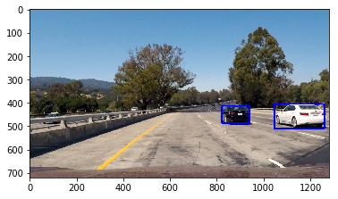

```python
img = draw_box(image, out_boxes, color=(0, 0, 255), thick=6, image_shape = [1280,780])
plt.imshow(img)
plt.show
```

Perfect. Doing detection on video!

```python
def process_image(img):
    yolo_outputs = yolo_head(yolo_model.output, anchors, 80)
    scores, boxes, classes = yolo_eval(yolo_outputs, image_shape)
    resized_image = cv2.resize(img, (608,608))
    image_data = np.array(resized_image, dtype='float32')
    image_data /= 255.
    image_data = np.expand_dims(image_data, 0)
    out_scores, out_boxes, out_classes =sess.run([scores, boxes, classes],feed_dict={yolo_model.input:image_data, K.learning_phase(): 0})
    img = draw_box(img, out_boxes, color=(0, 0, 255), thick=6, image_shape = [1920,1200])
    return img
```

```python
#sess = K.get_session()
from moviepy.editor import VideoFileClip
video_output = 'output/project_video.mp4'
clip1 = VideoFileClip("project_video.mp4")
white_clip = clip1.fl_image(process_image)
white_clip.write_videofile(video_output, audio=False)
```

```
[MoviePy] >>>> Building video output/project_video.mp4
[MoviePy] Writing video output/project_video.mp4
```